# Student Engagement (via Canvas) and Academic Achievement

Project 3

490356641, 480048691

University of Sydney | DATA1001 | May 2019

# Executive Summary

The aim of this report is to investigate how access to online learning spaces such as “Canvas” influences a student’s academic achievement.

The main discoveries are that students who accessed Canvas during breaks had higher final marks than those who did not. Secondly, the more frequently a student accessed Canvas, the higher they were likely to score. However, quite strangely, the group of 7 units with the highest median marks accessed Canvas at a similar frequency to the group with the lowest median marks. This indicates that further research needs to be carried out before definite conclusions can be made.

# Full Report

## Initial Data Analysis (IDA)

**Stakeholders and Purpose**

There are two main stakeholders that may benefit from this study. The first group is **Canvas**, an online learning management system that is adopted by more than 3,000 universities worldwide (Canvas, 2019). Founded in 2008, the company’s goal is to make learning and teaching easier and more readily available on mobile devices (ibid.). This study, which aims to identify the relationship between a student’s academic achievement and access to Canvas, is valuable for Canvas as the company can use the analysis to allocate their resources efficiently and improve their network system to help students persist in their studies.

The second group is the **University of Sydney** (USYD). Following USYD’s organizational changes in early 2018, the university decided to change its online learning space from Blackboard to Canvas (USYD, 2019). Thus, this data report is valuable for the university’s quality management system as it provides insights into the impacts of the transition after one year.

**Data Integrity and Ethics**

The respondents involved in this dataset include 10,845 students who completed junior Mathematics units of study in 2018. The dataset can be deemed reliable since it was collated by the University of Sydney’s Institutional Analytics and Planning (IAP), the department responsible for managing student data. Controls were used to eliminate inconsistencies among the responses. Moreover, the study attempted to eliminate ethical issues by ensuring anonymity of the participants for each variable investigated.

**Limitations**

The data only tells us whether the student accessed canvas **at least once** during that week or if they did not. It does not provide information on how many times the student accessed Canvas or how long they spent on it. Moreover, the study is limited to the number of students who were enrolled in a Junior Mathematics Unit of Study. Hence, it is not representative of the entire student body of the University and therefore, any conclusions made cannot be reliably extended to the entire population.

## Research Question: How Does Access to Canvas Affect A Student’s Academic Achievement?

The university environment is highly individual-based and one’s academic achievement depends greatly on his or her engagement in their studies. Given the fact that Canvas provides a learning space where students can access their course materials, accessing Canvas can be seen as **engagement in learning**. The following research questions attempt to learn the effects of accessing Canvas on a student’s academic achievement.

### 1. Do students who access Canvas on their breaks tend to have higher final marks than those who don’t?

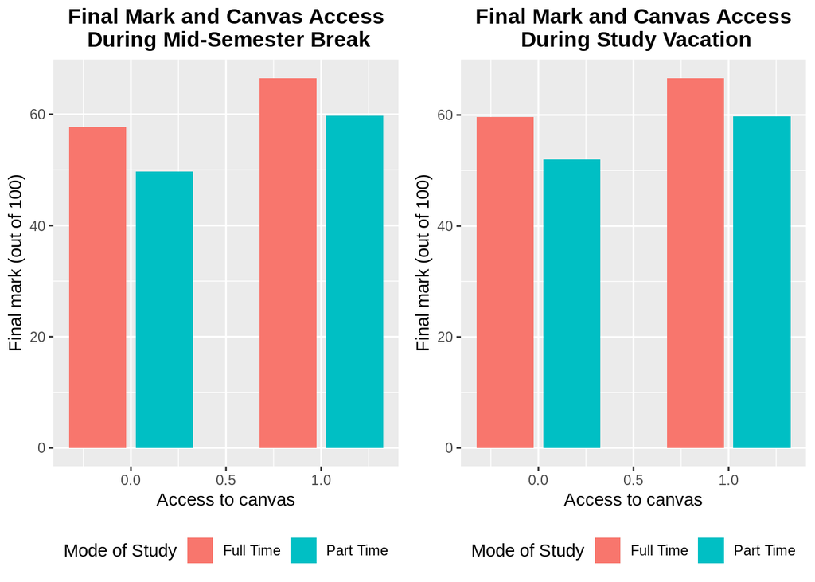

```r
midsem_bar <- ggplot(data, aes(midsem, mark, fill = study_mode)) +
  stat_summary(fun.y = mean, geom = "bar", position = "position_dodge"(width = 0.70), width = 0.6) +
  labs(x = "Access to canvas", y = "Final mark (out of 100)", fill = "Mode of Study") +
  ggtitle("Final Mark and Canvas Access\n During Mid-Semester Break") +
  theme(legend.position = "bottom") +
  theme(plot.title = element_text(hjust = 0.5, face = "bold"))

stuvac_bar <- ggplot(data, aes(stuvac, mark, fill = study_mode)) +
  stat_summary(fun.y = mean, geom = "bar", position = "position_dodge"(width = 0.70), width = 0.6) +
  labs(x = "Access to canvas", y = "Final mark (out of 100)", fill = "Mode of Study") +
  ggtitle("Final Mark and Canvas Access\n During Study Vacation") +
  theme(legend.position = "bottom") +
  theme(plot.title = element_text(hjust = 0.5, face = "bold"))

grid.arrange(midsem_bar, stuvac_bar, nrow = 1)
```

For the purpose of investigating the question, 3 participants with “Unknown” mode of study were removed from the original dataset.

**Percentage of students studying Full Time**

```r
sum(study_mode=="Full Time") / length(study_mode) * 100
```

```
## [1] 97.09463
```

**Percentage of students studying Part Time**

```r
sum(study_mode=="Part Time") / length(study_mode) * 100
```

```
## [1] 2.905368
```

The bar plot above shows the final marks of students who accessed Canvas during the mid-semester break and during the study vacation. 1 indicates logging in to Canvas at least once during that week and 0 indicates not logging in at all. From the data, it can be seen that for both full-time and part-time students, those that accessed Canvas at least once during the two breaks scored higher than those who did not.

These results correspond to a 2015 study in South Korea by Jo et al. where students who logged in more frequently in the online Learning Management System (LMS) scored higher than those who did not. However, as the paper suggests, there are likely to be other confounding factors such as the time spent on the LMS, which courses they are taking, etc. Coverage bias is also at play since approximately 97% of participants are studying full-time. Hence, no definite conclusions can be made.

### 2. Is there a relationship between final marks and the frequency of accessing Canvas?

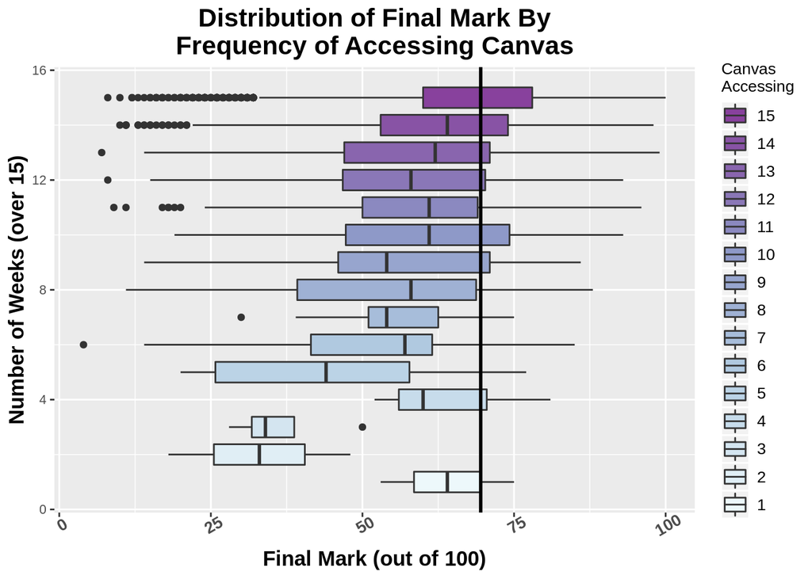

```r
library(RColorBrewer)

# Classic palette BuPu, with 4 colors
coul = brewer.pal(4, "BuPu")

# Adding more tones to the palette
coul = colorRampPalette(coul)(15)

# Creating graph
ggplot(data = data, mapping = aes(x = canvas_sum, y = mark)) +
  geom_boxplot(aes(fill=factor(canvas_sum))) +
  scale_fill_manual(values = coul) +
  guides(fill = guide_legend(reverse = TRUE)) +
  coord_flip() +
  geom_hline(yintercept = median(mark[canvas_sum == "15"]), size = 1, color = "black") +
  labs(x = "Number of Weeks (over 15)",
       y = "Final Mark (out of 100)",
       fill = "Canvas\nAccessing", title = "Distribution of Final Mark By\nFrequency of Accessing Canvas", ylab = "Number of weeks") +
  theme(
   text = element_text(size = 10),
   legend.text = element_text(size = 10),
   axis.text.x = element_text(face = "bold", size = 10, angle = 30),
   axis.title = element_text(size = 13, face = "bold"),
   plot.title = element_text(hjust = 0.5, face = "bold", size = 16),
  )
```

The boxplot above shows the relationship between students’ final marks and their frequency of accessing Canvas. It can be seen that the more frequently a student accessed Canvas, the higher they tended to score. In fact, students who accessed Canvas for all 15 weeks of the semester had the highest median final mark (69.5) and they were the only group that also scored full marks. This is supported by a study conducted in 2015 in a Portugese high school by Alves et al., which shows a positive correlation between access to a Virtual Learning Environment (VLE) and a student’s performance.

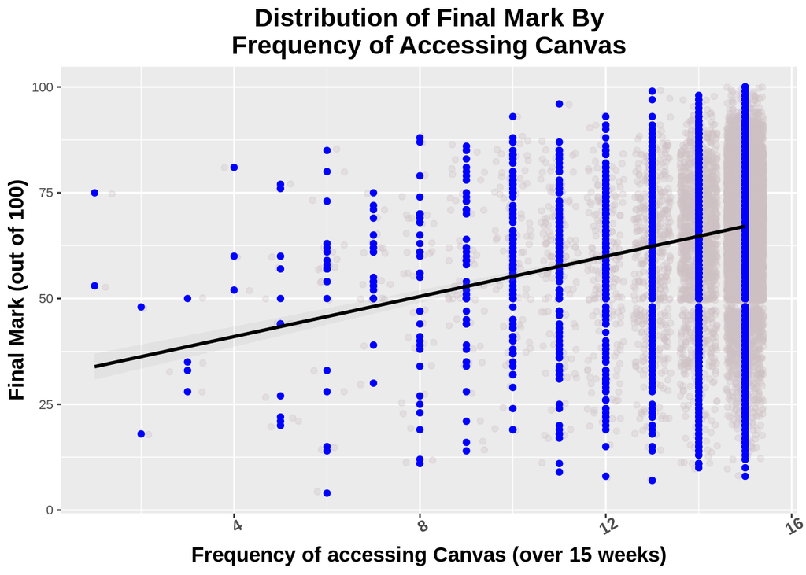

```r
ggplot(data, mapping = aes(y = mark, x = canvas_sum)) +
  geom_jitter(alpha = 0.3, color = "lavenderblush3") +
  geom_point(color = "blue") +
  geom_smooth(method = "lm", alpha = 0.1, colour = "Black") +
  labs(x = "Frequency of accessing Canvas (over 15 weeks)", y = "Final Mark (out of 100)", color = "Mark") +
  ggtitle("Distribution of Final Mark By\nFrequency of Accessing Canvas") +
  theme(
   text = element_text(size = 10),
   legend.text = element_text(size = 10),
   axis.text.x = element_text(face = "bold", size = 10, angle = 30),
   axis.title = element_text(size = 13, face = "bold"),
   plot.title = element_text(hjust = 0.5, face = "bold", size = 16),
  ) +
  theme(legend.position = "bottom")
```

```r
l = lm(mark ~ canvas_sum)
summary(l)
```

```
##
## Call:
## lm(formula = mark ~ canvas_sum)
##
## Residuals:
##     Min      1Q  Median      3Q     Max
## -59.099  -8.356   1.901  10.273  41.105
##
## Coefficients:
##             Estimate Std. Error t value Pr(>|t|)
## (Intercept)  31.5238     1.6816   18.75   <2e-16 ***
## canvas_sum    2.3717     0.1152   20.58   <2e-16 ***
## ---
## Signif. codes:  0 '***' 0.001 '**' 0.01 '*' 0.05 '.' 0.1 ' ' 1
##
## Residual standard error: 14.59 on 10840 degrees of freedom
## Multiple R-squared:  0.0376, Adjusted R-squared:  0.03751
## F-statistic: 423.5 on 1 and 10840 DF,  p-value: < 2.2e-16
```

```r
l$coefficients
```

```
## (Intercept)  canvas_sum
##   31.523770    2.371686
```

**Correlation**

```r
cor(canvas_sum, mark)
```

```
## [1] 0.1939024
```

The scatterplot above represents the same data. For `x = canvas_sum` and `y = mark`, the regression line (black) is approximately
$$y = 31.52 + 2.37x$$
The glitter represents the concentration of the number of students and their total weeks of accessing Canvas at least once. From this, there seems to be an over-representation of students who accessed Canvas 15 weeks over the semester, implying that Canvas LMS has become greatly integrated with USYD’s learning environment.

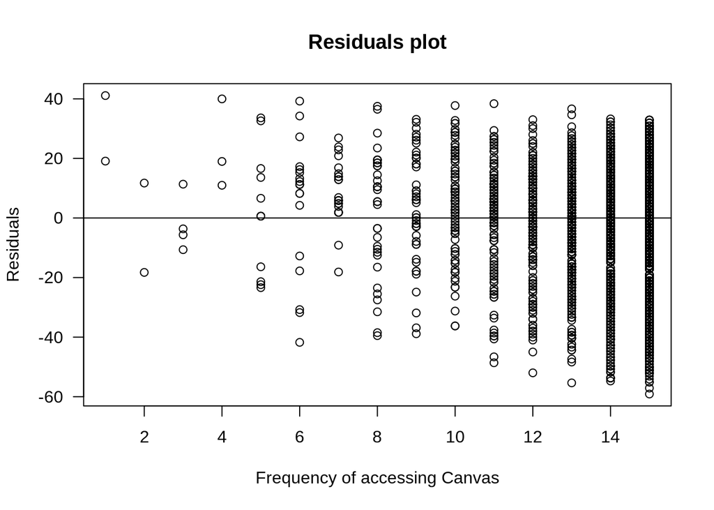

```r
plot(canvas_sum, l$residuals, main = "Residuals plot", xlab = "Frequency of accessing Canvas", ylab = "Residuals", las = 1)
abline(h = 0)
```

In this residual plot, the data shows “fanning”, i.e. the residuals are more spread out for larger values of x. This implies that there might be hidden confounders that affect the relationship between the two variables and so care needs to be taken when making any conclusions.

### 3. Is there any difference in student engagement between different groups of Units of Study?

For the purpose of investigating this question, the original dataset was broken down to two separate datasets, one with the 7 units of study with the highest median marks and one with the 7 units with the lowest median marks. The two groups were then tagged with “Upper” and “Lower” respectively. The distribution of the median final mark by units of study, grouped, are shown as follows:

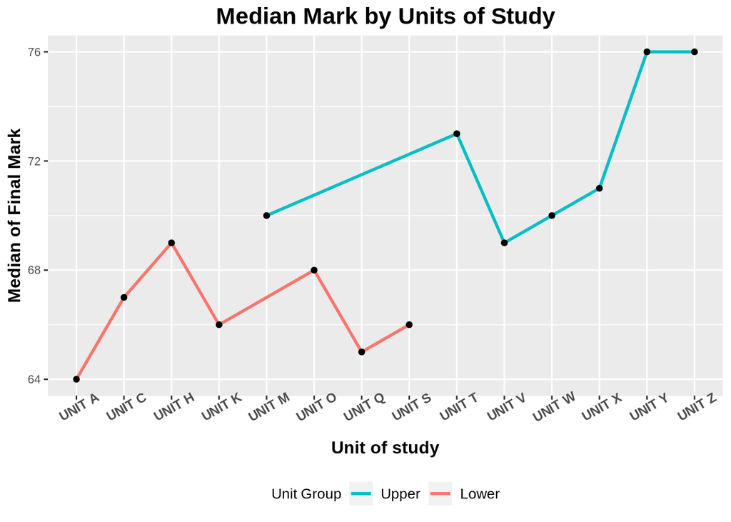

```r
line = ggplot(total, aes(total$Unit.of.Study.Identifier, total$Mark))
line +
  stat_summary(fun.y = median, geom = "line", aes(group = total$tag, color = total$tag), size = 1) +
  stat_summary(fun.y = median, geom = "point") +
  labs(
   title = "Median Mark by Units of Study",
   x = "Unit of study",
   y = "Median of Final Mark",
   color = "Unit Group") +
  guides(color = guide_legend(reverse = TRUE)) +
  theme(
   text = element_text(size = 10),
   legend.text = element_text(size = 10),
   axis.text.x = element_text(face = "bold", size = 9, angle = 30),
   axis.title = element_text(size = 12, face = "bold"),
   plot.title = element_text(hjust = 0.5, face = "bold", size = 16),
   plot.subtitle = element_text(hjust = 0.5, size = 19)
  ) + theme(legend.position = "bottom")
```

We are interested in learning the differences (if any) in student engagement between these two groups of units. Therefore, we computed the median number of weeks a student accessed Canvas for each unit of study, grouped by their median marks.

[figure not shown]

```r
line = ggplot(total, aes(total$Unit.of.Study.Identifier, total$canvas_sum))
line +
  stat_summary(fun.y = median, geom = "line", aes(group = total$tag, color = total$tag), size = 1) +
  stat_summary(fun.y = median, geom = "point") +
  labs(
   title = "Frequency of accessing Canvas by Units of Study",
   y = "Frquency of accessing Canvas \n by Median",
   color = "Unit Group") +
  guides(color = guide_legend(reverse = TRUE)) +
  scale_x_discrete(name ="Units of Study",
                    limits=c("UNIT A", "UNIT C", "UNIT H", "UNIT K", "UNIT O", "UNIT Q", "UNIT S", "UNIT M", "UNIT T", "UNIT V", "UNIT W", "UNIT X", "UNIT Y", "UNIT Z")) +
  theme(
   text = element_text(size = 10),
   legend.text = element_text(size = 10),
   axis.text.x = element_text(face = "bold", size = 9, angle = 30),
   axis.title = element_text(size = 12, face = "bold"),
   plot.title = element_text(hjust = 0.5, face = "bold", size = 16),
   plot.subtitle = element_text(hjust = 0.5, size = 19)
  )
```

It can be seen that there is, quite surprisingly, no difference between the two groups. The study by Boulton et al. in London provides that “high VLE activity is associated with high grades, but low activity does not necessarily imply low grades”. This is once again, due to hidden confounders such as how the unit is being taught, the difficulty level of the units (e.g. advanced), etc. Therefore, these confounders must be accounted for and more data should be collected before any definite and reliable conclusions can be made.

### Conclusion

In conclusion, further research needs to be carried out that accounts for hidden confounding factors. Moreover, encompassing more majors in future studies will provide a clearer insight into how access to online learning spaces such as Canvas affects a student’s academic achievement.

## References

- Alves, P., Morais, C., & Miranda, L. (2017, March). *The Influence of Virtual Learning Environments in Student’s Performance.*. Universal Journal of Educational Research, 5(3), 517-527. Polytechnic Institute of Bragança. Portugal. Retrieved from: https://www.researchgate.net/publication/317307245_The_Influence_of_Virtual_Learning_Environments_in_Students'_Performance
- Boulton, C.A, Kent, C., & Williams, H. (2018, November). *Virtual learning environment engagement and learning outcomes at a ‘bricks-and-monstar’ university.* Computers & Education, 126, 129-142. Retrieved from: https://www.sciencedirect.com/science/article/pii/S036013151830174X
- Canvas by Instructure (2019). *About us.* Canvas. Retrieved from: https://www.canvaslms.com/about-us/
- Fredricks, J. A., Blumenfeld, P. C., & Paris, A. H. (2004). *School engagement: Potential of the concept, state of the evidence.* Review of Educational Research, 74(1), 59-109.
- Jo, I., Yu, T., & Lee, H. (2014, September 11). *Relations between Student Online Learning Behavior and Academic Achievement in Higher Education: A Learning Analytics Approach.* Emerging Issues in Smart Learning. 275-287. Retrieved from: https://link.springer.com/chapter/10.1007/978-3-662-44188-6_38
- Univeristy of Sydney (2019). *Learning in Canvas.* The Univeristy of Sydney website. Retrieved from: https://sydney.edu.au/students/canvas.html